# STA 380 Homework 2: Dalton, Haines, Jansen, Karnes

## Flights at ABIA

- We know we can ignore the variable ‘Year’, as all the values for Year will be 2008
- We want to investigate arrival delays considering delays (ideally we can predict how much later we would arrive if we know how delayed our flight is)
- According to the Federal Aviation Administration a flight is considered delayed if it’s departure is 15 minutes later than its scheduled time - this is the standard we will use when analyzing the data

```r
abia = read.csv('ABIA.csv')

#Separating the data into delayed and ontime flights
delayed = abia[abia$DepDelay >=15, ]
on.time = abia[abia$DepDelay < 15, ]
```

We want to check a couple aspects of the data now that we have it separated between delayed and ontime:

Looking first at distance travelled and its effect on arrival delay:

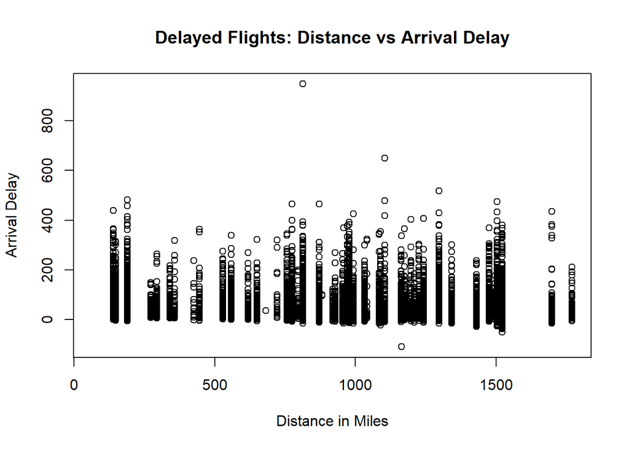

```r
delay.dist = plot(delayed$Distance,delayed$ArrDelay, xlab = 'Distance in Miles', ylab = 'Arrival Delay', main = 'Delayed Flights: Distance vs Arrival Delay')
```

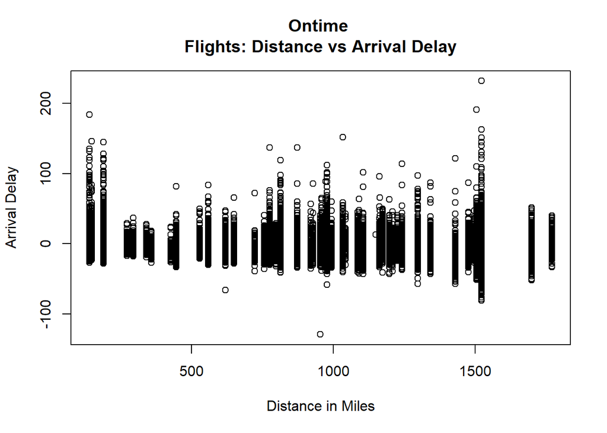

```r
ontime.dist = plot(on.time$Distance, on.time$ArrDelay, xlab = 'Distance in Miles', ylab = 'Arrival Delay', main = 'Ontime
Flights: Distance vs Arrival Delay')
```

From these scatter plots, we can see that the range of Arrival Delay for ontime flights has more values below 0 (meaning the flight arrived early) than the delayed flights. However, distance does not seem to affect the arrival delay for both delayed and ontime flights. The scatter plots look almost uniform, meaning that distance is no real indication of an arrival delay.

We can also see by comparing the two scatterplots that departure delay tends to affect arrival delay as a majority of the flights either arrive ontime or much later. It is much rarer to see a flight arrive early given it has been delayed.

We will calculate the bayesian probability below to put numerical backing to our claims from the graphs.

```r
#Probability a flight arrives early given it has been delayed
#probability early and delayed / probability delayed
early.and.delayed = nrow(delayed[delayed$ArrDelay<0,])/nrow(abia)
prob.delayed = nrow(delayed)/nrow(abia)
early.given.delayed = early.and.delayed/prob.delayed

#Probability a flight arrives early given it is ontime
#probability early and on time / probability ontime
early.and.ontime = nrow(on.time[on.time$ArrDelay<0, ])/nrow(abia)
prob.ontime = nrow(on.time)/nrow(abia)
early.given.ontime = early.and.ontime/prob.ontime
```

- The probability of arriving early given your flight was delayed is: 0.0906479
- The proability of arriving early given your flight was ontime is: 0.6572801

This makes logical sense, as it is more difficult to arrive early if you departed late.

Looking at how departure delay affects arrival delay:

```r
#mean arrival delay for delayed flights

arrival.delay = delayed$ArrDelay
#omitting NA values
delay.arrival = na.omit(arrival.delay)
average.arrival.delay = mean(delay.arrival)

#For comparison - what is the mean arrival delay for ontime flights
ontime.arrival = on.time$ArrDelay
#omitting NA values
on.timearrival = na.omit(ontime.arrival)
average.ontime.arrival = mean(on.timearrival)
```

- The average arrival delay in minutes of delayed flights are: 52.7796403
- The average arrival delay in minutes of ontime flights are: -3.2766219

So now that we know the average arrival delay of a delayed flight, can we discern the typical arrival delay if we know how delayed a flight is?

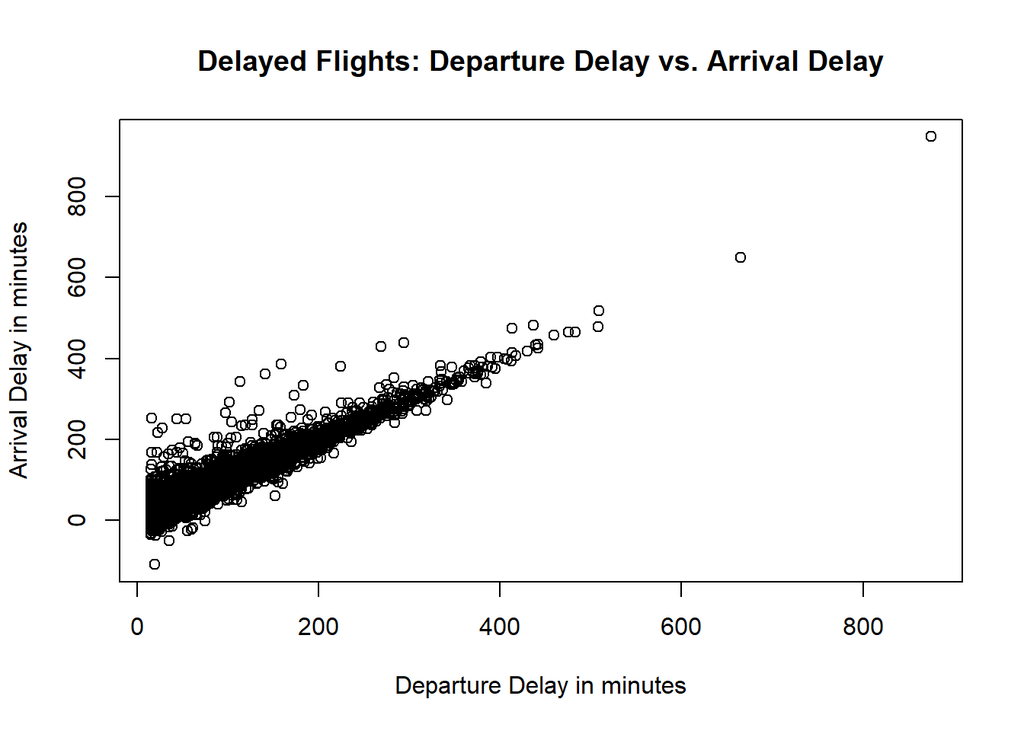

```r
#Plot of departure delay and arrival delay
the.plot = plot(delayed$DepDelay, delayed$ArrDelay, xlab ='Departure Delay in minutes', ylab = 'Arrival Delay in minutes', main = 'Delayed Flights: Departure Delay vs. Arrival Delay')
```

From the scatter plot above we can see a positive correlation between departure delay and arrival delay. Once again, this makes logical sense as the later you are, the harder it is to arrive on time (or close to on time).

## Practice with association rule mining

```r
##read in text file (this was in a webpage format)
grocery = readLines("groceries.txt")
library(arules)
##select lines from file
mypattern = '<td id="([^<]*)" class="blob-code blob-code-inner js-file-line">([^<]*)</td>'


datalines = grep(mypattern,grocery[659:39997],value=TRUE)


##parse through to get desired information
datalines = gsub("<td","",datalines)
datalines = gsub("id=","",datalines)
datalines= gsub("[A-Z0-9]","",datalines)
datalines=gsub("\"\"","",datalines)
datalines = gsub("class=\"","",datalines)
datalines = gsub("blob-code blob-code-inner js-file-line","",datalines)
datalines = gsub("\"","",datalines)
datalines = gsub(">","",datalines)
datalines = gsub("</td","",datalines)
datalines = trimws(datalines, which="left")
length(datalines)
```

```
## [1] 9835
```

```r
datalines = strsplit(datalines,",")




###change to transaction format
#' arules transactions
trans = as(datalines, "transactions")

##run apriori and inspect associations
##chose support=.008 to be able to view less frequent items
rules = apriori(trans,
                      parameter=list(support=.008, confidence=.5, maxlen=6))
```

```
## Apriori
##
## Parameter specification:
##  confidence minval smax arem  aval originalSupport maxtime support minlen
##         0.5    0.1    1 none FALSE            TRUE       5   0.008      1
##  maxlen target   ext
##       6  rules FALSE
##
## Algorithmic control:
##  filter tree heap memopt load sort verbose
##     0.1 TRUE TRUE  FALSE TRUE    2    TRUE
##
## Absolute minimum support count: 78
##
## set item appearances ...[0 item(s)] done [0.00s].
## set transactions ...[169 item(s), 9835 transaction(s)] done [0.00s].
## sorting and recoding items ... [100 item(s)] done [0.00s].
## creating transaction tree ... done [0.00s].
## checking subsets of size 1 2 3 4 done [0.00s].
## writing ... [30 rule(s)] done [0.00s].
## creating S4 object  ... done [0.00s].
```

```r
inspect(rules)
```

```
##      lhs                        rhs                    support confidence     lift
## [1]  {baking powder}         => {whole milk}       0.009252669  0.5229885 2.046793
## [2]  {frozen vegetables,
##       other vegetables}      => {whole milk}       0.009659380  0.5428571 2.124552
## [3]  {curd,
##       yogurt}                => {whole milk}       0.010066090  0.5823529 2.279125
## [4]  {curd,
##       other vegetables}      => {whole milk}       0.009862735  0.5739645 2.246296
## [5]  {brown bread,
##       other vegetables}      => {whole milk}       0.009354347  0.5000000 1.956825
## [6]  {butter,
##       root vegetables}       => {whole milk}       0.008235892  0.6377953 2.496107
## [7]  {butter,
##       yogurt}                => {whole milk}       0.009354347  0.6388889 2.500387
## [8]  {butter,
##       other vegetables}      => {whole milk}       0.011489578  0.5736041 2.244885
## [9]  {domestic eggs,
##       root vegetables}       => {whole milk}       0.008540925  0.5957447 2.331536
## [10] {domestic eggs,
##       other vegetables}      => {whole milk}       0.012302999  0.5525114 2.162336
## [11] {fruit/vegetable juice,
##       yogurt}                => {whole milk}       0.009456024  0.5054348 1.978094
## [12] {root vegetables,
##       whipped/sour cream}    => {other vegetables} 0.008540925  0.5000000 2.584078
## [13] {root vegetables,
##       whipped/sour cream}    => {whole milk}       0.009456024  0.5535714 2.166484
## [14] {whipped/sour cream,
##       yogurt}                => {whole milk}       0.010879512  0.5245098 2.052747
## [15] {other vegetables,
##       whipped/sour cream}    => {whole milk}       0.014641586  0.5070423 1.984385
## [16] {pip fruit,
##       root vegetables}       => {other vegetables} 0.008134215  0.5228758 2.702304
## [17] {pip fruit,
##       root vegetables}       => {whole milk}       0.008947636  0.5751634 2.250988
## [18] {pip fruit,
##       yogurt}                => {whole milk}       0.009557702  0.5310734 2.078435
## [19] {other vegetables,
##       pip fruit}             => {whole milk}       0.013523132  0.5175097 2.025351
## [20] {pastry,
##       yogurt}                => {whole milk}       0.009150991  0.5172414 2.024301
## [21] {citrus fruit,
##       root vegetables}       => {other vegetables} 0.010371124  0.5862069 3.029608
## [22] {citrus fruit,
##       root vegetables}       => {whole milk}       0.009150991  0.5172414 2.024301
## [23] {root vegetables,
##       tropical fruit}        => {other vegetables} 0.012302999  0.5845411 3.020999
## [24] {root vegetables,
##       tropical fruit}        => {whole milk}       0.011997966  0.5700483 2.230969
## [25] {tropical fruit,
##       yogurt}                => {whole milk}       0.015149975  0.5173611 2.024770
## [26] {root vegetables,
##       yogurt}                => {other vegetables} 0.012913066  0.5000000 2.584078
## [27] {root vegetables,
##       yogurt}                => {whole milk}       0.014539908  0.5629921 2.203354
## [28] {rolls/buns,
##       root vegetables}       => {other vegetables} 0.012201322  0.5020921 2.594890
## [29] {rolls/buns,
##       root vegetables}       => {whole milk}       0.012709710  0.5230126 2.046888
## [30] {other vegetables,
##       yogurt}                => {whole milk}       0.022267412  0.5128806 2.007235
```

```r
#We found a threshold of >2.4 for lift allowed us to see the items that increase in likelihood most given their association
#Confidence of >0.58 showed a strong association and gave us the top end of the confidence spectrum
inspect(subset(rules, subset=lift > 2.4 & confidence > 0.58))
```

```
##     lhs                  rhs                    support confidence     lift
## [1] {butter,
##      root vegetables} => {whole milk}       0.008235892  0.6377953 2.496107
## [2] {butter,
##      yogurt}          => {whole milk}       0.009354347  0.6388889 2.500387
## [3] {citrus fruit,
##      root vegetables} => {other vegetables} 0.010371124  0.5862069 3.029608
## [4] {root vegetables,
##      tropical fruit}  => {other vegetables} 0.012302999  0.5845411 3.020999
```

Overall, when observing a wide range of support, lift, and confidence, we found that the rhs was pretty much always whole milk and other vegetables. This makes sense as these are both items that are kitchen staples and likely purchased on every grocery run. Whole milk is associated with butter and yogurt, which is to be expected as they are all dairy products. Lastly, we can see an association in produce where people who purchase root vegetables, citrus fruit, and tropical fruit are 3 times more likely to buy other vegetables. This makes sense as many people who buy these products are interested in health.